# Homework 2

# Task 1

### Part a

In the first task of the second homework, the aim is mainly about understanding the structure of a given data through PCA (Principle Component Analysis) and MDS (Multidimensional scheduling). The data that is used for this part is a Musk data that consists the features of given 475 molecule instances. These instances, by scientists, are divided into classes according to their feature values. F rom these classes, the scientists argue that the class is either a “Musk” type or “Non-Musk”. The main goal is to predict whether a given instance of a molecule is belong to “Musk” or “Non-musk” class.

I have took the features columns to understand how they represent the variance of the data (bag class and the bag id).

```r
require(data.table)
ourmusk<-read.csv("Musk1.csv")
musk<-ourmusk[,3:168]
head(musk)
```

A data.frame: 6 × 166

| X42 <int> | X.198 <int> | X.109 <int> | X.75 <int> | X.117 <int> | X11 <int> | X23 <int> | X.88 <int> | X.28 <int> | X.27 <int> | ... | X.238 <int> | X.74 <int> | X.129 <int> | X.120.2 <int> | X.38.1 <int> | X30 <int> | X48.1 <int> | X.37.2 <int> | X6.1 <int> | X30.1 <int> |
| --- | --- | --- | --- | --- | --- | --- | --- | --- | --- | --- | --- | --- | --- | --- | --- | --- | --- | --- | --- | --- |
| 42 | -191 | -142 | -65 | -117 | 55 | 49 | -170 | -45 | 5 | ... | -238 | -302 | 60 | -120 | -39 | 31 | 48 | -37 | 5 | 30 |
| 42 | -191 | -142 | -75 | -117 | 11 | 49 | -161 | -45 | -28 | ... | -238 | -73 | -127 | -120 | -38 | 30 | 48 | -37 | 5 | 31 |
| 42 | -198 | -110 | -65 | -117 | 55 | 23 | -95 | -28 | 5 | ... | -238 | -302 | 60 | -120 | -39 | 30 | 48 | -37 | 6 | 30 |
| 42 | -198 | -102 | -75 | -117 | 10 | 24 | -87 | -28 | -28 | ... | -238 | -73 | -127 | 51 | 128 | 144 | 43 | -30 | 14 | 26 |
| 42 | -191 | -142 | -65 | -117 | 55 | 49 | -170 | -45 | 6 | ... | -238 | -300 | 61 | 51 | 127 | 143 | 42 | -31 | 14 | 26 |
| 42 | -190 | -142 | -75 | -117 | 12 | 49 | -161 | -45 | -29 | ... | -238 | -72 | -125 | 51 | 124 | 143 | 44 | -30 | 14 | 29 |

Then, I have applied PCA using "prcomp" function and by summarizing the pca, observed that about 75% of the difference between these data rows can be explained by the first 4 features. Therefore, I have chosen these 4 features to reflect the data instead of 166 features.

```r
musk.pca <- prcomp(musk, retx=TRUE, center = FALSE,scale. = TRUE)
```

When I plot the Variances of Principal components, it is observed that the variances look like exponentially distributed. This is also another reason to choose first 4 components. The effect of the other features decreases smoothly.

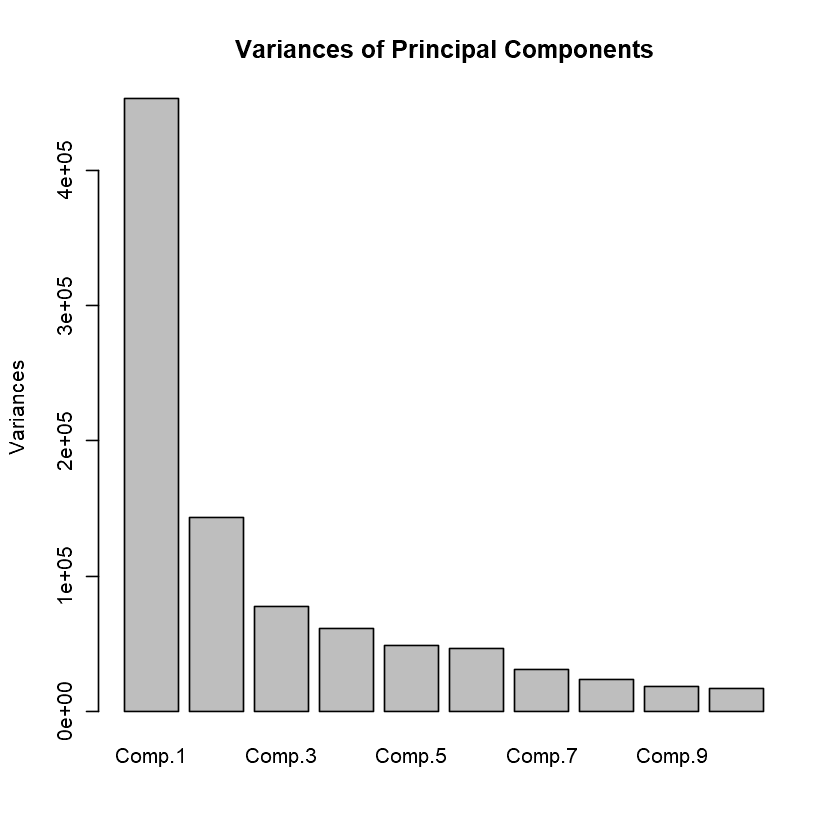

```r
musk.pca2 <- princomp(musk, retx=FALSE, center = FALSE,scale. = FALSE)
plot(musk.pca2, main = "Variances of Principal Components")
```

Therefore the features that we determined are as follows:  
X42  
X.198  
X.109  
X.75

After choosing the features to explain the data, I have looked at the relations between these features and plotted the features one by one to see if they are correlated and if they form groups according to their bag class.

The figures below shows that there is no correlation between these components and they represent the molecules efficiently. For instance, one can see that the distribution of the blue and the red points depends on the x axis in the first plot.

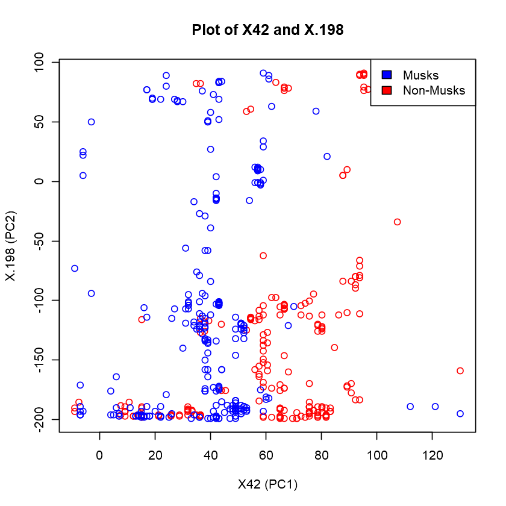

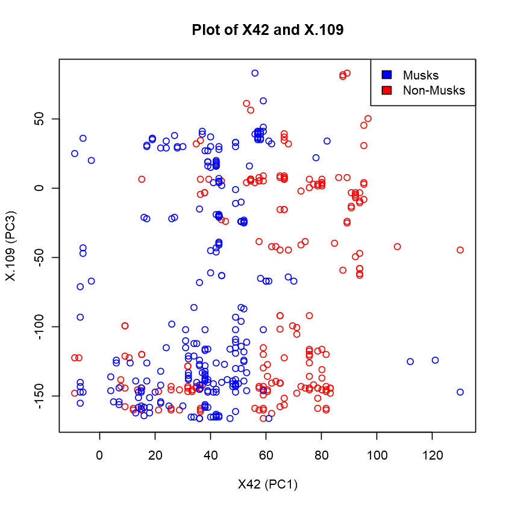

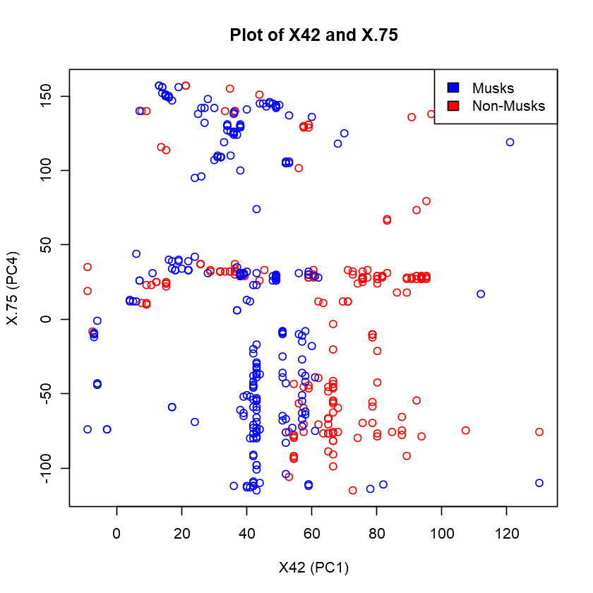

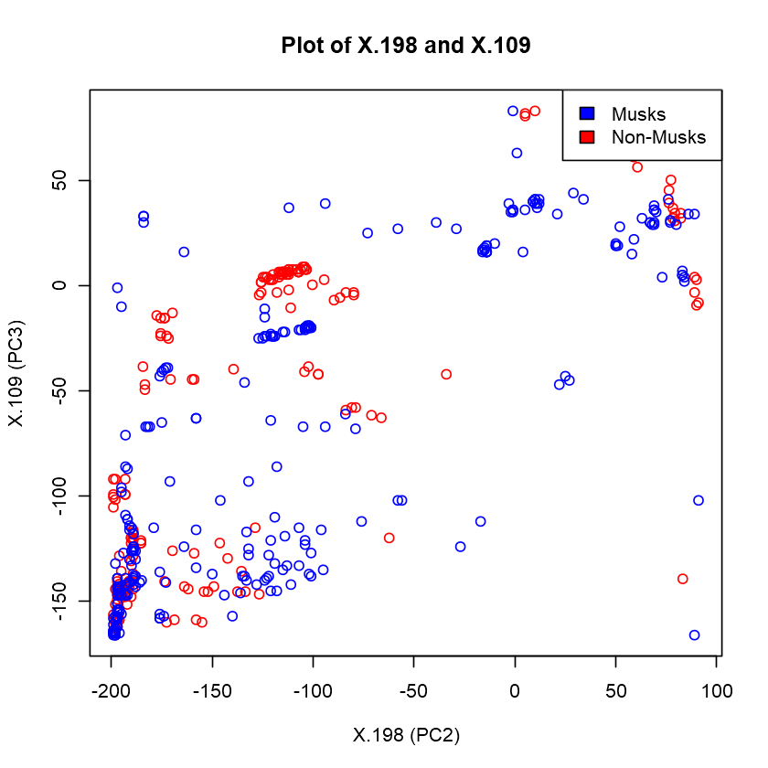

[figure not shown]

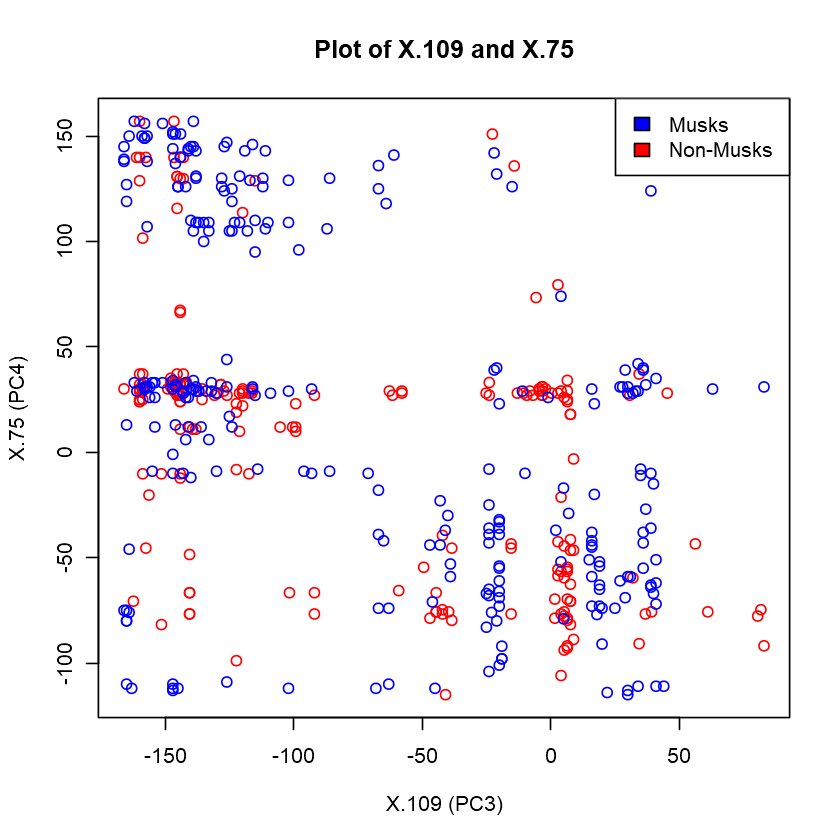

```r
plot(ourmusk[ourmusk$X1==1,]$X42,ourmusk[ourmusk$X1==1,]$X.198, col="red", axes=FALSE, xlab="",ylab="", main = "Plot of X42 and X.198")
par(new=TRUE)
plot(ourmusk[ourmusk$X1==0,]$X42,ourmusk[ourmusk$X1==0,]$X.198, col="blue",xlab="X42 (PC1)",ylab="X.198 (PC2)")
legend("topright",
c("Musks","Non-Musks"),
fill=c("blue","red")
)

plot(ourmusk[ourmusk$X1==1,]$X42,ourmusk[ourmusk$X1==1,]$X.109, col="red", axes=FALSE, xlab="",ylab="", main = "Plot of X42 and X.109")
par(new=TRUE)
plot(ourmusk[ourmusk$X1==0,]$X42,ourmusk[ourmusk$X1==0,]$X.109, col="blue",xlab="X42 (PC1)",ylab="X.109 (PC3)")
legend("topright",
c("Musks","Non-Musks"),
fill=c("blue","red")
)

plot(ourmusk[ourmusk$X1==1,]$X42,ourmusk[ourmusk$X1==1,]$X.75, col="red", axes=FALSE, xlab="",ylab="", main = "Plot of X42 and X.75")
par(new=TRUE)
plot(ourmusk[ourmusk$X1==0,]$X42,ourmusk[ourmusk$X1==0,]$X.75, col="blue",xlab="X42 (PC1)",ylab="X.75 (PC4)")
legend("topright",
c("Musks","Non-Musks"),
fill=c("blue","red")
)

plot(ourmusk[ourmusk$X1==1,]$X.198,ourmusk[ourmusk$X1==1,]$X.109, col="red", axes=FALSE, xlab="",ylab="", main = "Plot of X.198 and X.109")
par(new=TRUE)
plot(ourmusk[ourmusk$X1==0,]$X.198,ourmusk[ourmusk$X1==0,]$X.109, col="blue",xlab="X.198 (PC2)",ylab="X.109 (PC3)")
legend("topright",
c("Musks","Non-Musks"),
fill=c("blue","red")
)

plot(ourmusk[ourmusk$X1==1,]$X.198,ourmusk[ourmusk$X1==1,]$X.75, col="red", axes=FALSE, xlab="",ylab="", main = "Plot of X42 and X.198")
par(new=TRUE)
plot(ourmusk[ourmusk$X1==0,]$X.198,ourmusk[ourmusk$X1==0,]$X.75, col="blue",xlab="X.198 (PC2)",ylab="X.75 (PC4)")
legend("topright",
c("Musks","Non-Musks"),
fill=c("blue","red")
)

plot(ourmusk[ourmusk$X1==1,]$X.109,ourmusk[ourmusk$X1==1,]$X.75, col="red", axes=FALSE, xlab="",ylab="", main = "Plot of X.109 and X.75")
par(new=TRUE)
plot(ourmusk[ourmusk$X1==0,]$X.109,ourmusk[ourmusk$X1==0,]$X.75, col="blue",xlab="X.109 (PC3)",ylab="X.75 (PC4)")
legend("topright",
c("Musks","Non-Musks"),
fill=c("blue","red")
)
```

### Part b

```r
averages<-aggregate( ourmusk$X42 ~ ourmusk$X1.1, ourmusk, mean,colnames=c("1","2"))
averages2<-aggregate( ourmusk$X.198 ~ ourmusk$X1.1, ourmusk, mean)
averages3<-aggregate( ourmusk$X.109 ~ ourmusk$X1.1, ourmusk, mean)
averages4<-aggregate( ourmusk$X.75 ~ ourmusk$X1.1, ourmusk, mean)
averages5<-aggregate( ourmusk$X.117 ~ ourmusk$X1.1, ourmusk, mean)
averages6<-aggregate( ourmusk$X11 ~ ourmusk$X1.1, ourmusk, mean)
averages7<-aggregate( ourmusk$X23 ~ ourmusk$X1.1, ourmusk, mean)
averages8<-aggregate( ourmusk$X.88 ~ ourmusk$X1.1, ourmusk, mean)
averages9<-aggregate( ourmusk$X.28 ~ ourmusk$X1.1, ourmusk, mean)
averages10<-aggregate( ourmusk$X.27 ~ ourmusk$X1.1, ourmusk, mean)
```

```r
averages[,3]<-averages2[,2]
averages[,4]<-averages3[,2]
averages[,5]<-averages4[,2]
averages[,6]<-averages5[,2]
averages[,7]<-averages6[,2]
averages[,8]<-averages7[,2]
averages[,9]<-averages8[,2]
averages[,10]<-averages9[,2]
averages[,11]<-averages10[,2]
```

```r
names(averages)=c("X1.1","X42avr","x.198avr","x.109avr","x.75avr","x.117avr","x11avr","x23avr","x.88avr","x.28avr","x.27avr","X1")
```

The plots below shows that the 5 of the components will represent the data efficiently and when we look at the summary of the pca, the cumulative proportion of these 5 components is 95% which shows that taking averages might be better than the first assumption.

```
Importance of components:
                            Comp.1     Comp.2     Comp.3     Comp.4     Comp.5
Standard deviation     109.2921324 89.6889513 77.2144264 74.3873382 62.7391432
Proportion of Variance   0.3217367  0.2166710  0.1605905  0.1490462  0.1060230
Cumulative Proportion    0.3217367  0.5384077  0.6989982  0.8480444  0.9540673
                            Comp.6     Comp.7       Comp.8       Comp.9
Standard deviation     26.78523012 21.7241983 17.050423454 11.857296743
Proportion of Variance  0.01932474  0.0127119  0.007830567  0.003786991
Cumulative Proportion   0.97339208  0.9861040  0.993934548  0.997721539
                           Comp.10
Standard deviation     9.197279709
Proportion of Variance 0.002278461
Cumulative Proportion  1.000000000
```

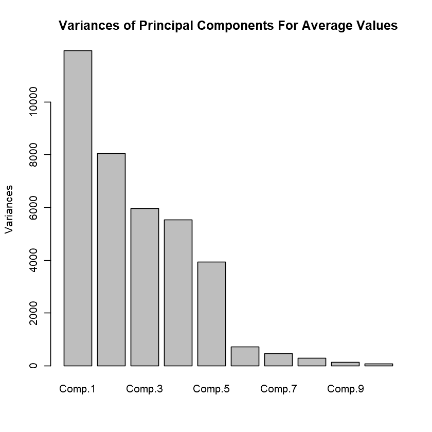

```r
musk_averages.pca <- princomp(averages[,2:11], retx=FALSE, center = FALSE,scale. = FALSE)
plot(musk_averages.pca, main = "Variances of Principal Components For Average Values")
summary(musk_averages.pca)
```

# Task 2

In the second task, I have requested to perform certain operations on images. The aim was to compress images using PCA.

### Part 1

In the first part, I read and display the image of Mona Lisa with size of 256x256

[figure not shown]

```r
require(jpeg)
monalisa <- readJPEG("mona lisa.jpg")
my_image <- as.raster(monalisa)
plot(my_image)
```

### Part 2

### a)

I have created the noise values and added them to the original pixel values and I took 1 for the new pixelss that exceeds 1.

```r
noise<-monalisa
for (i in 1:256){
    for(j in 1:256){
        for(k in 1:3){
            noise[i:i,j:j,k:k] <-runif(1,min(monalisa),max(monalisa)/10)
        }
    }
}
```

[figure not shown]

```r
noisy_monalisa<-monalisa+noise

for (i in 1:256){
    for(j in 1:256){
        for(k in 1:3){
            if(noisy_monalisa[i:i,j:j,k:k]>1)
           noisy_monalisa[i:i,j:j,k:k]<-1
        }
    }
}
new_image<-as.raster(noisy_monalisa)
plot(new_image)
```

### b)

Then I display the Three colour factors seperately.

[figure not shown]

[figure not shown]

[figure not shown]

```r
r<-apply(noisy_monalisa[,,1],2,rev)
g<-apply(noisy_monalisa[,,2],2,rev)
b<-apply(noisy_monalisa[,,3],2,rev)
image(1:ncol(r),1:nrow(r), as.matrix(t(r)), col=rgb(0:255,0,0,max=255),xlab="x",ylab="y",main="Red Channel")
image(1:ncol(g),1:nrow(g), as.matrix(t(g)), col=rgb(0,0:255,0,max=255),xlab="x",ylab="y",main="Green Channel")
image(1:ncol(b),1:nrow(b), as.matrix(t(b)), col=rgb(0,0,0:255,max=255),xlab="x",ylab="y",main="Blue Channel")
```

### Part 3

I have converted the image to a grayscale one using image editor.

[figure not shown]

```r
grey_monalisa <- readJPEG("graynoisymonalisa.jpg")
my_image_grey <- as.raster(grey_monalisa)
plot(my_image_grey)
```

I have extract the list of patches and I have chosen 5x5 matrices as patches.

```r
xcenters<-c(rep(3:254,252))
ycenters<-c(rep(3:254, each=252))
x<-array(1:256*256*3*1, dim=c(256,256,1,1))
x[,,1,1]<-grey_monalisa[,,1]
patches_list<-extract_patches(x,xcenters,ycenters,5,5,boundary_conditions = 0L)
patches_for_pca <- data.frame(matrix(unlist(patches_list), nrow=length(patches_list), byrow=T))
head(patches_for_pca)
```

A data.frame: 6 × 25

| X1 <dbl> | X2 <dbl> | X3 <dbl> | X4 <dbl> | X5 <dbl> | X6 <dbl> | X7 <dbl> | X8 <dbl> | X9 <dbl> | X10 <dbl> | ... | X16 <dbl> | X17 <dbl> | X18 <dbl> | X19 <dbl> | X20 <dbl> | X21 <dbl> | X22 <dbl> | X23 <dbl> | X24 <dbl> | X25 <dbl> |
| --- | --- | --- | --- | --- | --- | --- | --- | --- | --- | --- | --- | --- | --- | --- | --- | --- | --- | --- | --- | --- |
| 0.5921569 | 0.5333333 | 0.4980392 | 0.5215686 | 0.5450980 | 0.5725490 | 0.5215686 | 0.4941176 | 0.5137255 | 0.5294118 | ... | 0.5450980 | 0.5294118 | 0.5176471 | 0.5215686 | 0.5176471 | 0.5607843 | 0.5529412 | 0.5450980 | 0.5411765 | 0.5333333 |
| 0.5333333 | 0.4980392 | 0.5215686 | 0.5450980 | 0.5411765 | 0.5215686 | 0.4941176 | 0.5137255 | 0.5294118 | 0.5254902 | ... | 0.5294118 | 0.5176471 | 0.5215686 | 0.5176471 | 0.5176471 | 0.5529412 | 0.5450980 | 0.5411765 | 0.5333333 | 0.5333333 |
| 0.4980392 | 0.5215686 | 0.5450980 | 0.5411765 | 0.5372549 | 0.4941176 | 0.5137255 | 0.5294118 | 0.5254902 | 0.5294118 | ... | 0.5176471 | 0.5215686 | 0.5176471 | 0.5176471 | 0.5372549 | 0.5450980 | 0.5411765 | 0.5333333 | 0.5333333 | 0.5568627 |
| 0.5215686 | 0.5450980 | 0.5411765 | 0.5372549 | 0.5490196 | 0.5137255 | 0.5294118 | 0.5254902 | 0.5294118 | 0.5450980 | ... | 0.5215686 | 0.5176471 | 0.5176471 | 0.5372549 | 0.5647059 | 0.5411765 | 0.5333333 | 0.5333333 | 0.5568627 | 0.5843137 |
| 0.5450980 | 0.5411765 | 0.5372549 | 0.5490196 | 0.5450980 | 0.5294118 | 0.5254902 | 0.5294118 | 0.5450980 | 0.5411765 | ... | 0.5176471 | 0.5176471 | 0.5372549 | 0.5647059 | 0.5686275 | 0.5333333 | 0.5333333 | 0.5568627 | 0.5843137 | 0.5921569 |
| 0.5411765 | 0.5372549 | 0.5490196 | 0.5450980 | 0.5450980 | 0.5254902 | 0.5294118 | 0.5450980 | 0.5411765 | 0.5450980 | ... | 0.5176471 | 0.5372549 | 0.5647059 | 0.5686275 | 0.5686275 | 0.5333333 | 0.5568627 | 0.5843137 | 0.5921569 | 0.5921569 |

```
Importance of components:
                          PC1     PC2     PC3     PC4     PC5     PC6     PC7
Standard deviation     4.9120 0.58198 0.57368 0.23324 0.21400 0.19633 0.11733
Proportion of Variance 0.9651 0.01355 0.01316 0.00218 0.00183 0.00154 0.00055
Cumulative Proportion  0.9651 0.97865 0.99181 0.99399 0.99582 0.99736 0.99791
                           PC8     PC9    PC10    PC11    PC12    PC13    PC14
Standard deviation     0.11048 0.10133 0.09584 0.06191 0.05555 0.05462 0.05004
Proportion of Variance 0.00049 0.00041 0.00037 0.00015 0.00012 0.00012 0.00010
Cumulative Proportion  0.99840 0.99881 0.99918 0.99933 0.99945 0.99957 0.99967
                          PC15    PC16    PC17    PC18    PC19    PC20    PC21
Standard deviation     0.04792 0.03348 0.03218 0.03130 0.02947 0.02228 0.02130
Proportion of Variance 0.00009 0.00004 0.00004 0.00004 0.00003 0.00002 0.00002
Cumulative Proportion  0.99977 0.99981 0.99985 0.99989 0.99993 0.99995 0.99996
                          PC22    PC23    PC24    PC25
Standard deviation     0.01979 0.01423 0.01417 0.01051
Proportion of Variance 0.00002 0.00001 0.00001 0.00000
Cumulative Proportion  0.99998 0.99999 1.00000 1.00000
```

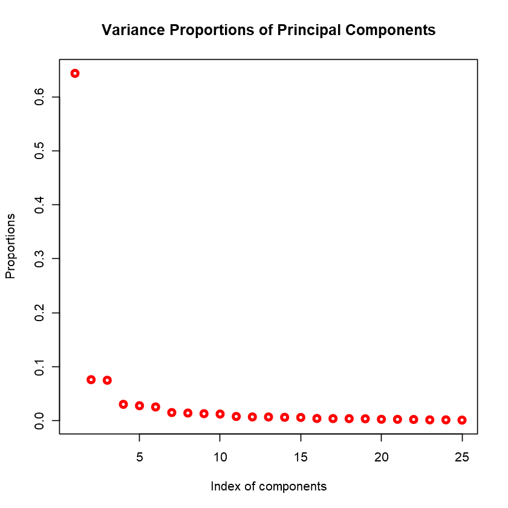

```r
patches.pca <- prcomp(patches_for_pca, retx=TRUE, center = TRUE,scale. = TRUE)
summary(patches.pca)
patches.pca$normalizedvar<-patches.pca$sdev/sum(patches.pca$sdev)
plot(patches.pca$normalizedvar, main = "Variance Proportions of Principal Components", col="red", ylab="Proportions", xlab="Index of components", lwd=3)
```

Then I have used the data in the x vector of the pca object to display the components as images. In here, the x values are not range from 0 to 1. Therefore, I have applied Normalization.

[figure not shown]

```r
first_component<-patches.pca$x[,1]
vector_comp1<-as.vector(t(first_component))
dim(vector_comp1)<-c(252,252)
normalize <- function(x) {
return ((x - min(x)) / (max(x) - min(x)))
}
normalized_vector_comp1<-normalize(vector_comp1)
image_comp1<-as.raster(normalized_vector_comp1)
plot(image_comp1,)
```

[figure not shown]

[figure not shown]

```r
second_component<-patches.pca$x[,2]
vector_comp2<-as.vector(t(second_component))
dim(vector_comp2)<-c(252,252)
normalized_vector_comp2<-normalize(vector_comp2)
image_comp2<-as.raster(normalized_vector_comp2)
plot(image_comp2)

third_component<-patches.pca$x[,3]
vector_comp3<-as.vector(t(third_component))
dim(vector_comp3)<-c(252,252)
normalized_vector_comp3<-normalize(vector_comp3)
image_comp3<-as.raster(normalized_vector_comp3)
plot(image_comp3)
```

```r
str(patches.pca)
```

```
List of 6
 $ sdev         : num [1:25] 4.912 0.582 0.574 0.233 0.214 ...
 $ rotation     : num [1:25, 1:25] -0.198 -0.199 -0.2 -0.199 -0.197 ...
  ..- attr(*, "dimnames")=List of 2
  .. ..$ : chr [1:25] "X1" "X2" "X3" "X4" ...
  .. ..$ : chr [1:25] "PC1" "PC2" "PC3" "PC4" ...
 $ center       : Named num [1:25] 0.384 0.383 0.381 0.38 0.379 ...
  ..- attr(*, "names")= chr [1:25] "X1" "X2" "X3" "X4" ...
 $ scale        : Named num [1:25] 0.191 0.192 0.192 0.192 0.192 ...
  ..- attr(*, "names")= chr [1:25] "X1" "X2" "X3" "X4" ...
 $ x            : num [1:63504, 1:25] -3.88 -3.68 -3.72 -3.97 -4.16 ...
  ..- attr(*, "dimnames")=List of 2
  .. ..$ : NULL
  .. ..$ : chr [1:25] "PC1" "PC2" "PC3" "PC4" ...
 $ normalizedvar: num [1:25] 0.6434 0.0762 0.0751 0.0305 0.028 ...
 - attr(*, "class")= chr "prcomp"
```

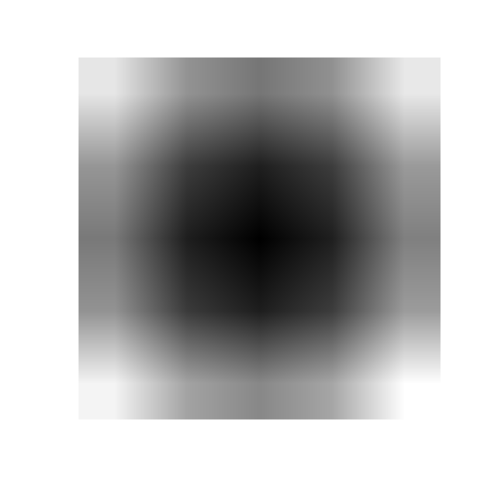

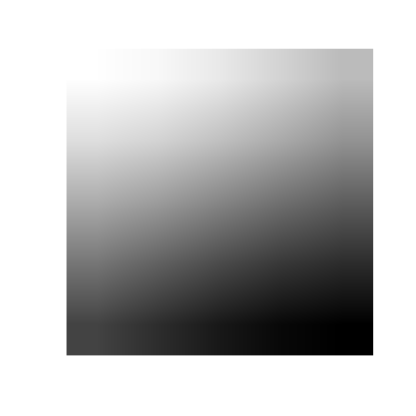

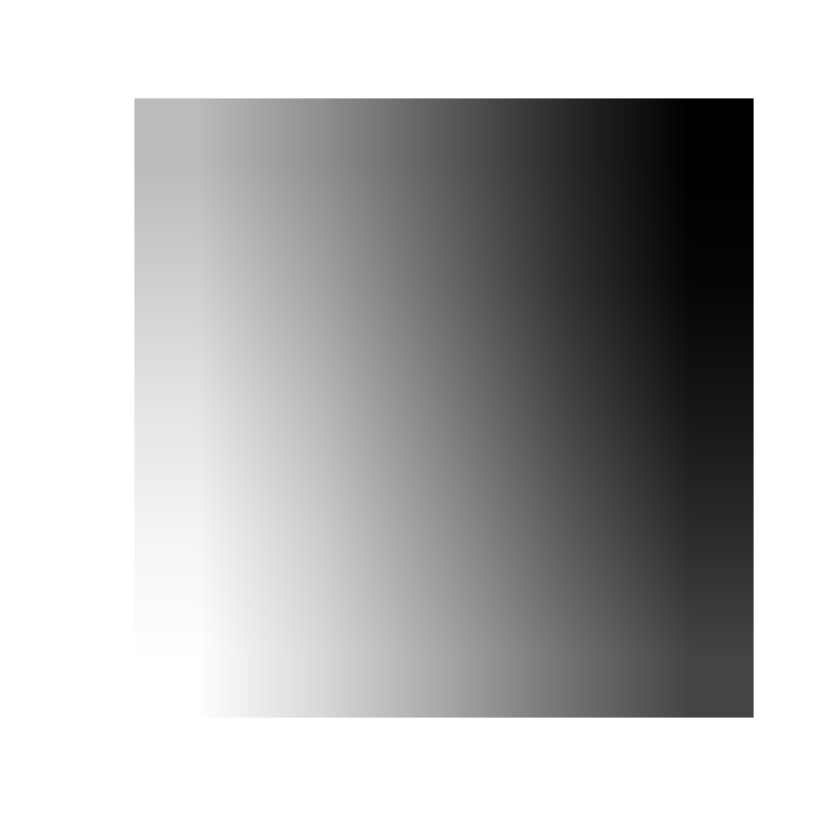

```r
first_component_rot<-patches.pca$rotation[,1]
vector_comp1_rot<-as.vector(t(first_component_rot))
dim(vector_comp1_rot)<-c(5,5)
normalized_vector_comp1_rot<-normalize(vector_comp1_rot)
image_comp1_rot<-as.raster(normalized_vector_comp1_rot)
plot(image_comp1_rot)

second_component_rot<-patches.pca$rotation[,2]
vector_comp2_rot<-as.vector(t(second_component_rot))
dim(vector_comp2_rot)<-c(5,5)
normalized_vector_comp2_rot<-normalize(vector_comp2_rot)
image_comp2_rot<-as.raster(normalized_vector_comp2_rot)
plot(image_comp2_rot)

third_component_rot<-patches.pca$rotation[,3]
vector_comp3_rot<-as.vector(t(third_component_rot))
dim(vector_comp3_rot)<-c(5,5)
normalized_vector_comp3_rot<-normalize(vector_comp3_rot)
image_comp3_rot<-as.raster(normalized_vector_comp3_rot)
plot(image_comp3_rot)
```

Finally, it is observed that the plot of the first component shows that in each patch, if we take the component that is in the middle of the patch, most of the data will be represented. This representation level will decrease when we take the component from the bottom or the right of the patch. However, the informations of these components are still necessary in order to show the image using these components.